# Time Series Analysis and Forecasting of Gold Prices per Gram

MTH6139 Coursework 1

Safa Mohamed

Spring term 2025

# Introduction

The price of gold exhibits significant variation over time and is considered a safe haven against financial market risks and economic uncertainty. Over time the price of gold changes as a response to economic conditions (Porqueras, 2021). This project analyses the historical price of gold per gram (USD) and applies time series techniques to explore trends and generate forecasts.

# Data

The data used in this project was obtained from Yahoo Finance (2026) using the quantmod package in R. The original series gave gold futures prices in US dollars per ounce. This was converted into US dollars per gram.

```r
library(quantmod)
library(forecast)
```

```r
getSymbols("GC=F", src = "yahoo")
```

```
## [1] "GC=F"
```

```r
gold_per_gram <- Cl(`GC=F`) / 31.1035

gold_df <- data.frame(
  date = index(gold_per_gram),
  price = as.numeric(gold_per_gram)
)
```

This dataset contains daily observations on gold prices from 2007.

# Time Series Plot

Firstly, I created a time series plot to help visualise the historical price per gram of gold.

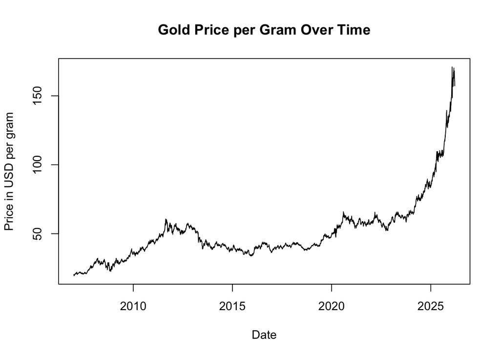

```r
plot(gold_df$date, gold_df$price,
     type = "l",
     main = "Gold Price per Gram Over Time",
     xlab = "Date",
     ylab = "Price in USD per gram")
```

The plot shows short-term fluctuations throughout the series, indicating volatility of gold prices over time. However, the overall pattern is dominated by a significant upward trend, suggesting the series is non-stationary and may require differencing before applying ARIMA models for forecasting.

# Autocorrelation Analaysis

Before fitting a forecasting model, it is useful to examine the relationship between current and past values of the time series. Financial data has missing values due to weekends and holidays, these were removed prior to plotting the ACF.

```r
gold_clean <- na.omit(as.numeric(gold_per_gram))
```

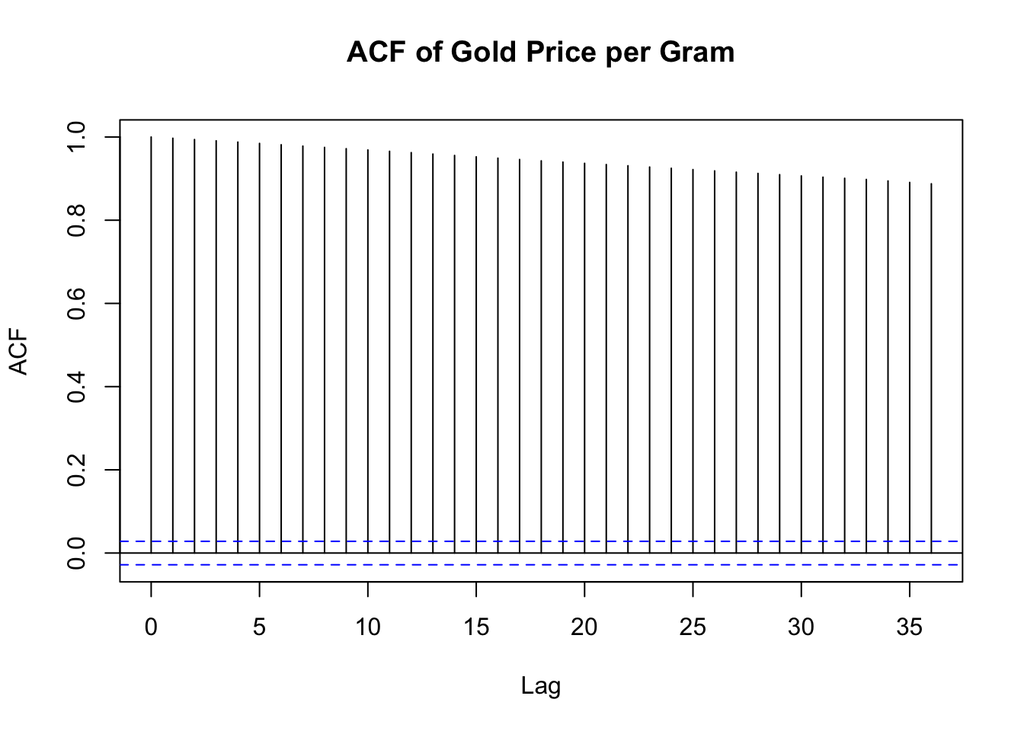

```r
acf(gold_clean, main = "ACF of Gold Price per Gram")
```

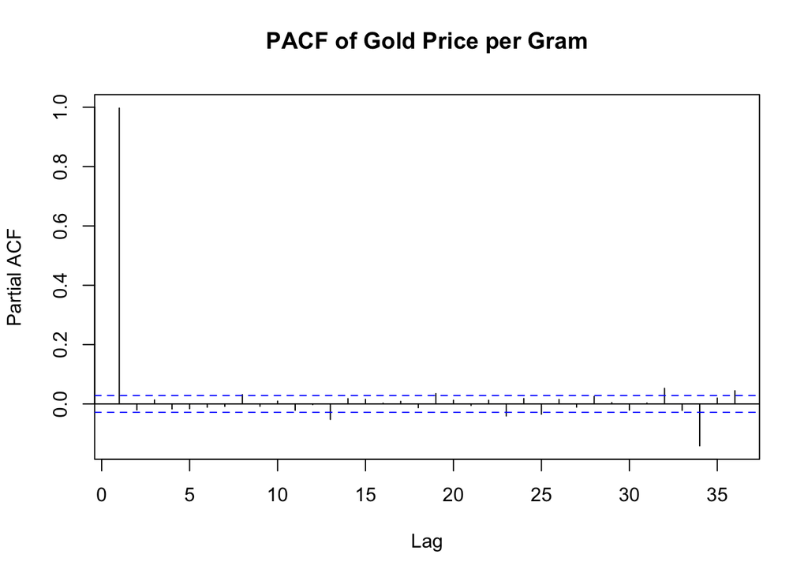

```r
pacf(gold_clean, main = "PACF of Gold Price per Gram")
```

The ACF plot shows strong positive autocorrelation across many lags, declining gradually over time. This suggests that the series is highly persistent and non-stationary. The PACF plot provides further evidence that historical values help explain current gold prices, supporting the use of an ARIMA model.